# 3’ End Sequencing Part 4: Visualize key 3’ UTR regions (Figure 4B)

Tina Kelliher

2/7/2022

## Read in the file containing data

Data type: Lexogen QuantSeq REV 3’ End RNA-Sequencing; 75 bp SE stranded reads

Raw data availability: https://www.ncbi.nlm.nih.gov/geo/query/acc.cgi?acc=GSE201901

Experimental strains: cspf5 cpsf6 double mutant & control

Experimental conditions: 25C LL; 72 hours growth; 0.25% glucose w/v + 0.17% arginine w/v medium

Experimental dates: 9/23/21 & 9/30/21 (N = 2 biological replicates per strain)

Full data pipeline: see Materials & Methods of manuscript

Data input to this script: sequencing read counts by 3’ UTR coordinate; Lexogen QuantSeq REV library preparation generates only 1 sequencing read per mRNA transcript at the immediate 3’ end; IGV software can be used first-pass to visualize poly(A) tail locations on genes of interest

igvtools was downloaded by CMK from the Broad Institute (https://software.broadinstitute.org/software/igv/igvtools_commandline)

igvtools was implemented via the command line (input files are mapped BAM files for each 3’ end sequencing experiment):

run_pipeline()

> for FILE in `ls`

> do

> igvtools count -z 0 -w 1 –query CM002236:5369646-5370051 ./Aligned.out.sorted.bam ./1_nab2_NCU16397_counts.wig /Users/f003906/N_crassa_NC12_withUTRs/FungiDB-45_UTRs.genome

> igvtools count -z 0 -w 1 –query CM002238:1904221-1904755 ./Aligned.out.sorted.bam ./2_rco-1_NCU06205_counts.wig /Users/f003906/N_crassa_NC12_withUTRs/FungiDB-45_UTRs.genome

> igvtools count -z 0 -w 1 –query CM002241:1762214-1762755 ./Aligned.out.sorted.bam ./3_ckb-1_NCU05485_counts.wig /Users/f003906/N_crassa_NC12_withUTRs/FungiDB-45_UTRs.genome

> igvtools count -z 0 -w 1 –query CM002236:4642603-4643148 ./Aligned.out.sorted.bam ./4_cka_NCU03124_counts.wig /Users/f003906/N_crassa_NC12_withUTRs/FungiDB-45_UTRs.genome

> igvtools count -z 0 -w 1 –query CM002239:1644074-1644641 ./Aligned.out.sorted.bam ./5_septal_NCU06565_counts.wig /Users/f003906/N_crassa_NC12_withUTRs/FungiDB-45_UTRs.genome

> igvtools count -z 0 -w 1 –query CM002237:964247-964862 ./Aligned.out.sorted.bam ./6_frh_NCU03363_counts.wig /Users/f003906/N_crassa_NC12_withUTRs/FungiDB-45_UTRs.genome

> igvtools count -z 0 -w 1 –query CM002238:2018007-2018640 ./Aligned.out.sorted.bam ./7_pkac-1_NCU06240_counts.wig /Users/f003906/N_crassa_NC12_withUTRs/FungiDB-45_UTRs.genome

> igvtools count -z 0 -w 1 –query CM002236:3284468-3285125 ./Aligned.out.sorted.bam ./8_csp-1_NCU02713_counts.wig /Users/f003906/N_crassa_NC12_withUTRs/FungiDB-45_UTRs.genome

> igvtools count -z 0 -w 1 –query CM002236:6815517-6816232 ./Aligned.out.sorted.bam ./9_wc-2_NCU00902_counts.wig /Users/f003906/N_crassa_NC12_withUTRs/FungiDB-45_UTRs.genome

> igvtools count -z 0 -w 1 –query CM002238:3240242-3241120 ./Aligned.out.sorted.bam ./10_set-2_NCU00269_counts.wig /Users/f003906/N_crassa_NC12_withUTRs/FungiDB-45_UTRs.genome

> igvtools count -z 0 -w 1 –query CM002242:3136163-3136825 ./Aligned.out.sorted.bam ./11_frq_NCU02265_counts.wig /Users/f003906/N_crassa_NC12_withUTRs/FungiDB-45_UTRs.genome

> igvtools count -z 0 -w 1 –query CM002241:2204875-2205750 ./Aligned.out.sorted.bam ./12_pabp-2_NCU03946_counts.wig /Users/f003906/N_crassa_NC12_withUTRs/FungiDB-45_UTRs.genome

> igvtools count -z 0 -w 1 –query CM002238:1040640-1041521 ./Aligned.out.sorted.bam ./13_prd-1_NCU07839_counts.wig /Users/f003906/N_crassa_NC12_withUTRs/FungiDB-45_UTRs.genome

> igvtools count -z 0 -w 1 –query CM002240:3235109-3236098 ./Aligned.out.sorted.bam ./14_set-1_NCU01206_counts.wig /Users/f003906/N_crassa_NC12_withUTRs/FungiDB-45_UTRs.genome

> igvtools count -z 0 -w 1 –query CM002240:5327530-5328783 ./Aligned.out.sorted.bam ./15_upf1_NCU04242_counts.wig /Users/f003906/N_crassa_NC12_withUTRs/FungiDB-45_UTRs.genome

> igvtools count -z 0 -w 1 –query CM002236:7565615-7567354 ./Aligned.out.sorted.bam ./16_ck-1a_NCU00685_counts.wig /Users/f003906/N_crassa_NC12_withUTRs/FungiDB-45_UTRs.genome

> done

In scripts not shown here, *.wig files were cleaned, replicates averaged, and Watson/Crick genes oriented as “distance from STOP” coordinates

```r
wt <- as.data.frame(read.table("./input_data/genes1-16_wild-type.txt", header=TRUE))

mut <- as.data.frame(read.table("./input_data/genes1-16_c5c6mutant.txt", header=TRUE))
```

## Generate Figure 4B heatmaps and data key

Acknowledgements: the code below is modified from Steve Haase’s lab code base at Duke University, especially the blue/yellow color scheme designations

Export heatmaps as SVG (900w x 600h) for Inkscape

Export key as SVG (400w x 400h) for Inkscape

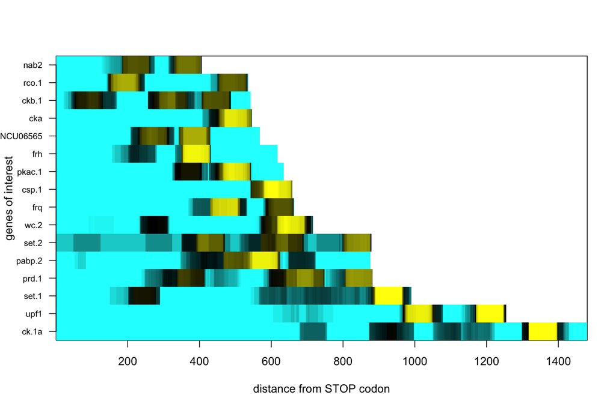

```r
wt_hm <- wt
mut_hm <- mut

points <- wt_hm[,1]
## distance from STOP codon coordinates are exactly the same in both wild-type and mutant data files

geneData_wt <- as.matrix(wt_hm[,2:ncol(wt_hm)])
geneData_mut <- as.matrix(mut_hm[,2:ncol(mut_hm)])
## remove the first column (coordinates) from each dataset

geneData_wt <- geneData_wt + 1
geneData_mut <- geneData_mut + 1
## this step gets rid of any non-NA "0s" in the data for the log transformation
## "NA" values in the original files will come out as white spaces in the heatmap

wt_normalizers <- apply(geneData_wt, 2, mean, na.rm=TRUE)

geneData_wt_meanNorm <- matrix(nrow=nrow(geneData_wt), ncol=ncol(geneData_wt))
for(i in 1:ncol(geneData_wt)){
  cur_3UTR <- geneData_wt[,i]
  cur_normalizer <- wt_normalizers[i]
  norm_data <- cur_3UTR / cur_normalizer
  geneData_wt_meanNorm[,i] <- norm_data
}

geneData_mut_meanNorm <- matrix(nrow=nrow(geneData_mut), ncol=ncol(geneData_mut))
for(j in 1:ncol(geneData_mut)){
  cur_3UTR <- geneData_mut[,j]
  cur_normalizer <- wt_normalizers[j]
  norm_data <- cur_3UTR / cur_normalizer
  geneData_mut_meanNorm[,j] <- norm_data
}
## mean-normalize COLUMN data TO THE WILD-TYPE MEANS, i.e. mutant poly(A) gene expression levels are comparable to wild-type

logData_wt <- as.matrix(log2(geneData_wt_meanNorm))
logData_mut <- as.matrix(log2(geneData_mut_meanNorm))
## log2-normalize the datasets for heatmap values

image(x=as.numeric(points), y=1:ncol(logData_wt), z=logData_wt, col=c(rgb(0, 49:1/49, 49:1/49), rgb(0:50/50, 0:50/50, 0)), xlab="distance from STOP codon", ylab="genes of interest", breaks=c(-100, seq(-3.0, 3.0, length=99), 100), yaxt="n")
axis(2, 1:ncol(logData_wt), labels=names(wt_hm[2:17]), las=2, cex.axis=0.75)
```

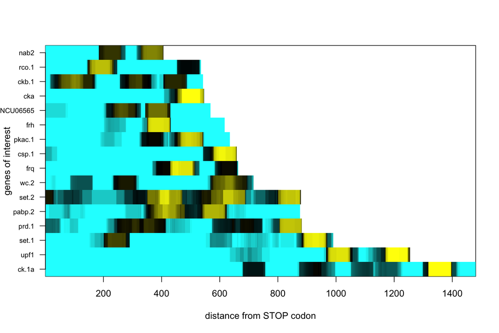

```r
## note that the above line is hard coded for this dataset's number of columns!

image(x=as.numeric(points), y=1:ncol(logData_mut), z=logData_mut, col=c(rgb(0, 49:1/49, 49:1/49), rgb(0:50/50, 0:50/50, 0)), xlab="distance from STOP codon", ylab="genes of interest", breaks=c(-100, seq(-3.0, 3.0, length=99), 100), yaxt="n")
axis(2, 1:ncol(logData_mut), labels=names(wt_hm[2:17]), las=2, cex.axis=0.75)
```

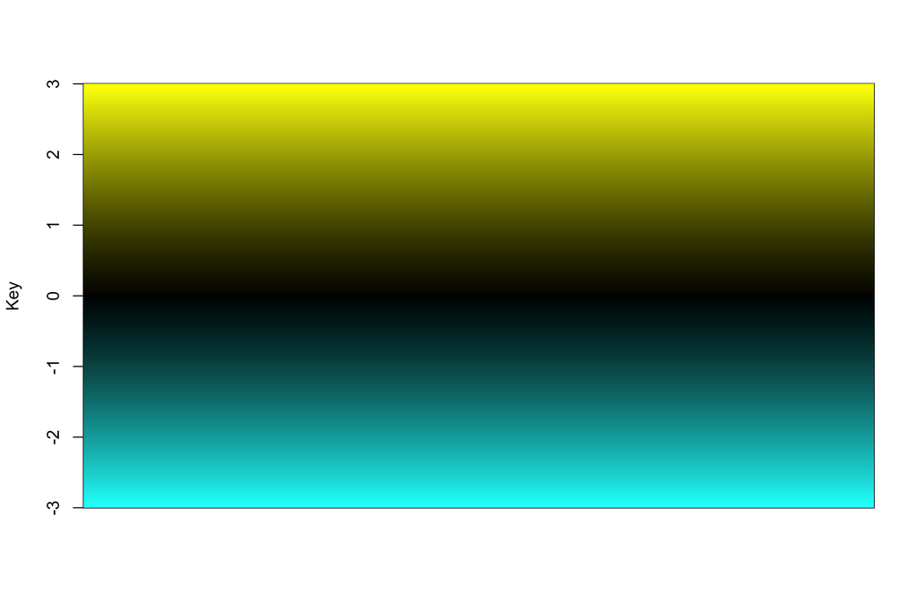

```r
## draw a key for these 2 heatmaps:

highCol <- 3.0
## change this value for the upper bound
lowCol <- -3.0
## change this value for the lower bound
cols <- c(rgb(0, 250:1/250, 250:1/250), rgb(0, 0, 0), rgb(1:250/250, 1:250/250, 0))
## this matches the standard yellow/blue color scheme above
tempDat <- matrix(seq(lowCol, highCol, length=1000), ncol=2, nrow=1000)
brks <- c(-10, seq(lowCol, highCol, length = (length(cols)-1)), 10)
image(1:ncol(tempDat), seq(lowCol, highCol, length=1000), t(tempDat), breaks=brks, col=cols, xlab="", ylab="Key", xaxt="n")
```